# R Notebook

## Математическое моделирование

### Кросс-валидация и бутстреп

В данной задаче выполняются следующие пункты:

- оценка точности модели методом перекрёстной выборки;
- методом проверочной выборки;
- методом перекрёстной проверки по отдельным наблюдениям (LOOCV);
- методом k-кратной перекрёстной проверки;
- применение бутстреп для оценки точности статистического параметра и оценок параметров модели

```r
library('GGally') # графики совместного разброса переменных
library('lmtest') # тесты остатков регрессионных моделей
library('FNN') # алгоритм kNN
library('mlbench')
library('MASS')
library('ISLR')
library('boot')
my.seed <- 1
```

## Метод перекрёстной проверки

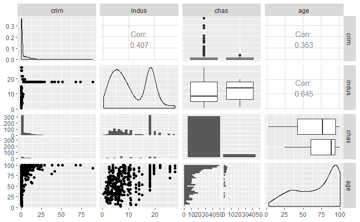

```r
# Пример на данных по районам: Boston
data(Boston) # открываем данные
?Boston
Boston <- Boston[,-c(2,5,6,8,9,10,11,12,13,14)]
Boston$chas <- as.factor(Boston$chas)
# графики разброса
ggpairs(Boston)
```

## Метод проверочной выборки

Он состоит в том, что мы отбираем одну тестовую выборку и будем считать на ней ошибку модели.

```r
n <- nrow(Boston)
# доля обучающей выборки
train.percent <- 0.5
# выбрать наблюдения в обучающую выборку
set.seed(my.seed)
inTrain <- sample(n, n*train.percent)
inTrain
```

```
  [1] 135 188 289 457 102 451 473 330 314  31 103  88 340 190 379 245 352 486 186 492 455 496
 [23] 316  61 129 488   7 184 416 163 230 285 234  89 391 315 374  51 339 193 383 301 364 257
 [45] 491 464  11 220 336 317 218 392 199 111  32  45 143 233 297 182 408 131 204 148 288 114
 [67] 211 337  37 466 443 366 151 145 206 385 372 168 333 411 481 303 170 138 320  86 299 469
 [89] 485  60 100  25 266 362 321 328 187 429 331 247 414 144 110 401 255 421  52 191 368 238
[111] 387 290 141 424  59   6 280  41 174 248 437 399 426  67 504 173 195  79  87 225 217  29
[133]  14 240 346 222 208 380 363 410 250 459 378  94 265 164  64 269  38 309 219 198 117 160
[155] 177 360 384  27  97  74  99 357 154 268 302 394  22 441 462 468 212 282 286 445 127 448
[177] 213 244 454 296  96  63 442 477 283 483 243 232 465 388 377 123 452 291 500 479  35 260
[199]  98 241  82 386 158 306  55 157 169  39  77 214 475  30 484 278 373  90 189 276 275 308
[221]  76  48  92 433 261 405  73  13 354 237 326 438 418 381 107 367 271 150 116 121 425 344
[243] 307 358 109  56 112 310 119 422 196 397 120
```

Построим модели для проверки точности. Вид моделей:
$$\hat{crim} = f(age,indus, chas)$$
**Линейная модель**: $\hat{crim} = \hat{\beta}_0 + \hat{\beta}_1 \cdot age + \hat{\beta}_2 \cdot indus + \hat{\beta}_3 \cdot chas$.

```r
# присоединить таблицу с данными: названия стоблцов будут доступны напрямую
attach(Boston)
# подгонка линейной модели на обучающей выборке
fit.lm.1 <- lm(crim ~ age + indus + chas, subset = inTrain)
# считаем MSE на тестовой выборке
mean((crim[-inTrain] - predict(fit.lm.1, Boston[-inTrain,]))^2)
```

```
[1] 58.21777
```

```r
# отсоединить таблицу с данными
detach(Boston)
```

Строим первую **квадратичную модель**: $\hat{crim} = \hat{\beta}_0 + \hat{\beta}_1 \cdot age^2 + \hat{\beta}_2 \cdot indus+ \hat{\beta}_3 \cdot chas$.

```r
# присоединить таблицу с данными: названия стоблцов будут доступны напрямую
attach(Boston)
# подгонка линейной модели на обучающей выборке
fit.lm.2 <- lm(crim ~ poly(age,2)+ indus + chas ,subset = inTrain)
# считаем MSE на тестовой выборке
mean((crim[-inTrain] - predict(fit.lm.2, Boston[-inTrain,]))^2)
```

```
[1] 56.99055
```

```r
# отсоединить таблицу с данными
detach(Boston)
```

Строим вторую **квадратичную модель**: $\hat{crim} = \hat{\beta}_0 + \hat{\beta}_1 \cdot indus^2 + \hat{\beta}_2 \cdot age+ \hat{\beta}_3 \cdot chas$.

```r
# присоединить таблицу с данными: названия стоблцов будут доступны напрямую
attach(Boston)
# подгонка линейной модели на обучающей выборке
fit.lm.3 <- lm(crim ~ age + poly(indus,2) + chas ,subset = inTrain)
# считаем MSE на тестовой выборке
mean((crim[-inTrain] - predict(fit.lm.3, Boston[-inTrain,]))^2)
```

```
[1] 56.69466
```

```r
# отсоединить таблицу с данными
detach(Boston)
```

Строим первую **кубическую модель**: $\hat{crim} = \hat{\beta}_0 + \hat{\beta}_1 \cdot age^3 + \hat{\beta}_2 \cdot indus + \hat{\beta}_3 \cdot chas$.

```r
# присоединить таблицу с данными: названия стоблцов будут доступны напрямую
attach(Boston)
# подгонка линейной модели на обучающей выборке
fit.lm.5 <- lm(crim ~ poly(age,3)+ indus + chas ,subset = inTrain)
# считаем MSE на тестовой выборке
mean((crim[-inTrain] - predict(fit.lm.5, Boston[-inTrain,]))^2)
```

```
[1] 55.85914
```

```r
# отсоединить таблицу с данными
detach(Boston)
```

Строим вторую **кубическую модель**: $\hat{crim} = \hat{\beta}_0 + \hat{\beta}_1 \cdot indus^3 + \hat{\beta}_2 \cdot age + \hat{\beta}_3 \cdot chas$.

```r
# присоединить таблицу с данными: названия стоблцов будут доступны напрямую
attach(Boston)
# подгонка линейной модели на обучающей выборке
fit.lm.4 <- lm(crim ~ age + poly(indus,3) + chas ,subset = inTrain)
# считаем MSE на тестовой выборке
mean((crim[-inTrain] - predict(fit.lm.4, Boston[-inTrain,]))^2)
```

```
[1] 50.83844
```

```r
# отсоединить таблицу с данными
detach(Boston)
```

Ошибка последней кубической модели оказалась наименьшей из всех построенных, следовательно она и будет являться наиболее пригодной для прогнозирования.

### Перекрёстная проверка по отдельным наблюдениям (LOOCV)

Это самый затратный в вычислительном плане метод, но и самый надёжный в плане оценки ошибки вне выборки. Попробуем применить его к линейной модели.

```r
# подгонка линейной модели на обучающей выборке
fit.glm <- glm(crim ~ age + indus + chas, data = Boston)
# считаем LOOCV-ошибку
cv.err <- cv.glm(Boston, fit.glm)
```

Теперь оценим точность полиномиальных моделей, меняя степень, в которой стоит регрессор.  
Вид модели 1:crim ~ poly(age,i) + indus + chas

```r
# вектор с LOOCV-ошибками
cv.err.loocv <- rep(0, 5)
names(cv.err.loocv) <- 1:5
# цикл по степеням полиномов
for (i in 1:5){
  fit.glm <- glm(crim ~ poly(age,i) + indus + chas, data = Boston)
  cv.err.loocv[i] <- cv.glm(Boston, fit.glm)$delta[1]
}
# результат
cv.err.loocv
```

[output not shown]

Вид модели 2:crim ~ age + poly(indus,i) + chas

```r
# вектор с LOOCV-ошибками
cv.err.loocv <- rep(0, 5)
names(cv.err.loocv) <- 1:5
# цикл по степеням полиномов
for (i in 1:5){
  fit.glm <- glm(crim ~ age + poly(indus,i) + chas, data = Boston)
  cv.err.loocv[i] <- cv.glm(Boston, fit.glm)$delta[1]
}
# результат
cv.err.loocv
```

[output not shown]

### k-кратная перекрёстная проверка

Проведём 5-кратную кросс-валидацию:

```r
# оценим точность полиномиальных моделей, меняя степень
# вектор с ошибками по 5-кратной кросс-валидации
cv.err.k.fold <- rep(0, 5)
names(cv.err.k.fold) <- 1:5
# цикл по степеням полиномов
for (i in 1:5){
  fit.glm <- glm(crim ~ age + poly(indus,i) + chas, data = Boston)
  cv.err.k.fold[i] <- cv.glm(Boston, fit.glm,
                             K = 5)$delta[1]
}
# результат
cv.err.k.fold
```

[output not shown]

Проведём 10-кратную кросс-валидацию:

```r
# оценим точность полиномиальных моделей, меняя степень
# вектор с ошибками по 10-кратной кросс-валидации
cv.err.k.fold <- rep(0, 10)
names(cv.err.k.fold) <- 1:10
# цикл по степеням полиномов
for (i in 1:10){
  fit.glm <- glm(crim ~ age + poly(indus,i) + chas, data = Boston)
  cv.err.k.fold[i] <- cv.glm(Boston, fit.glm,
                             K = 10)$delta[1]
}
# результат
cv.err.k.fold
```

[output not shown]

```r
err.test
```

[output not shown]

## Бутстреп

### Точность оценки параметра регрессии

При построении модели регрессии проблемы в остатках приводят к неверной оценке ошибок параметров. Обойти эту проблему можно, применив для расчёта этих ошибок бутстреп.

```r
boot(Boston, boot.fn, 1000)
```

```
ORDINARY NONPARAMETRIC BOOTSTRAP


Call:
boot(data = Boston, statistic = boot.fn, R = 1000)


Bootstrap Statistics :
       original        bias    std. error
t1* -3.86979127 -0.0287147264 0.494620951
t2*  0.04951804  0.0002217635 0.008703169
t3*  0.38581635  0.0029202760 0.051693557
t4* -3.02343988 -0.0194853173 0.622807107
```